# Insights Covered

# Programming tools and technologies

In this section, we will delve into the various programming tools and technologies that developers use in their daily workflows. This includes an analysis of the most popular programming languages, frameworks, DBMS, and other tools that are essential for modern software development. By understanding the tools and technologies favored by developers, we can gain insights into current trends and preferences within the tech industry.

This bar graph illustrates the top 15 most used programming languages among survey respondents.

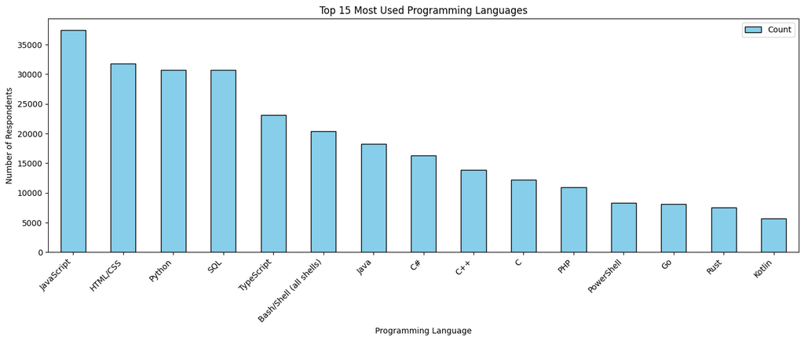

# Key Insights

- Javascript is the most popular programming language in 2024. The trend has been the same for almost a decade.
- Javascript is followed by HTML/CSS indicating that web development is the most pursued topic.
- Python and SQL are also among the top languages, highlighting their importance in data analysis and backend development.

The bar graph shows the most used Databases in 2024

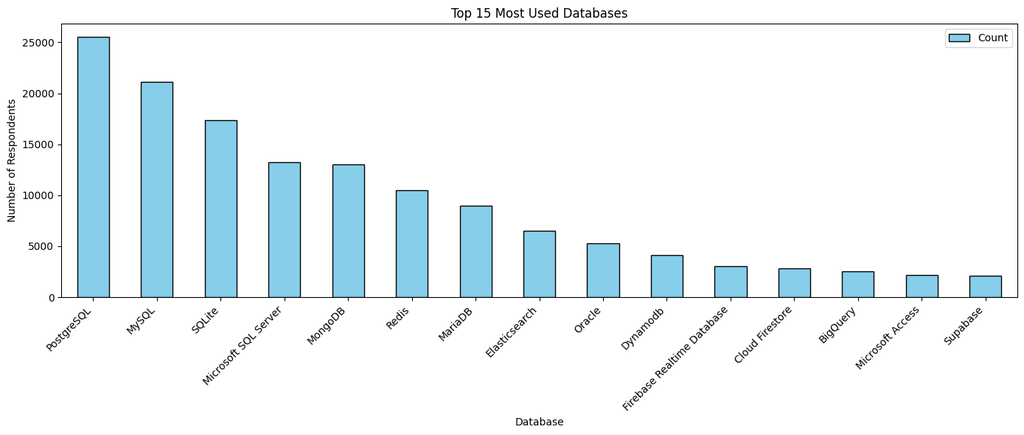

# Key Insights

- PostgreSQL is the most used database in 2024, followed by MySQL, SQLite, and Microsoft SQL Server, highlighting the popularity of SQL among developers.
- Dynamic databases like MongoDB, popular for web development, and Redis for in-memory data storage are also among the top choices.

The graph below shows the top 15 most used development-related platforms.

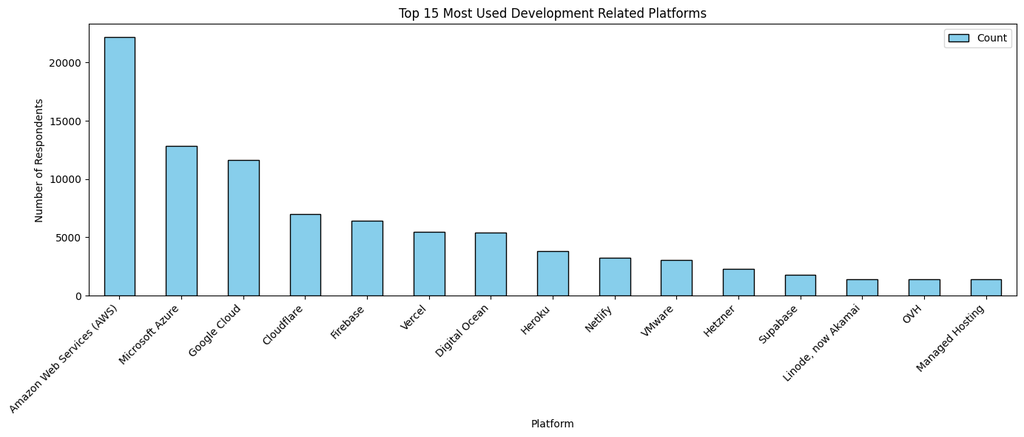

# Key Insights

- Amazon Web Services has significantly more users that any of it's competitor, having more than 22,000 developers working with it in 2024.
- It is followed by Microsoft Azure and Google Cloud which also belong to the big names in the industry with around 12,000 users each.

The graph below shows the top most used Web Frameworks in 2024

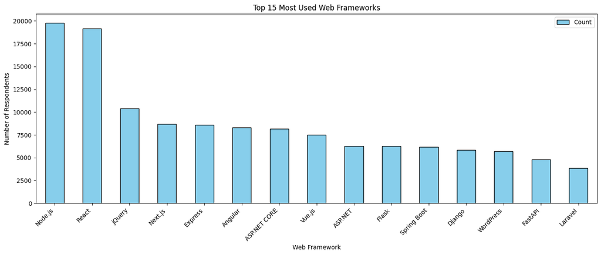

# Key Insights

- The most used web frameworks in 2024 are Node.js and React, highlighting the popularity of the MERN tech stack.
- These are followed by jQuery, Next.js, and Express, which are also widely used web frameworks.

The graph below shows the most used Tools and Technologies by the development industry.

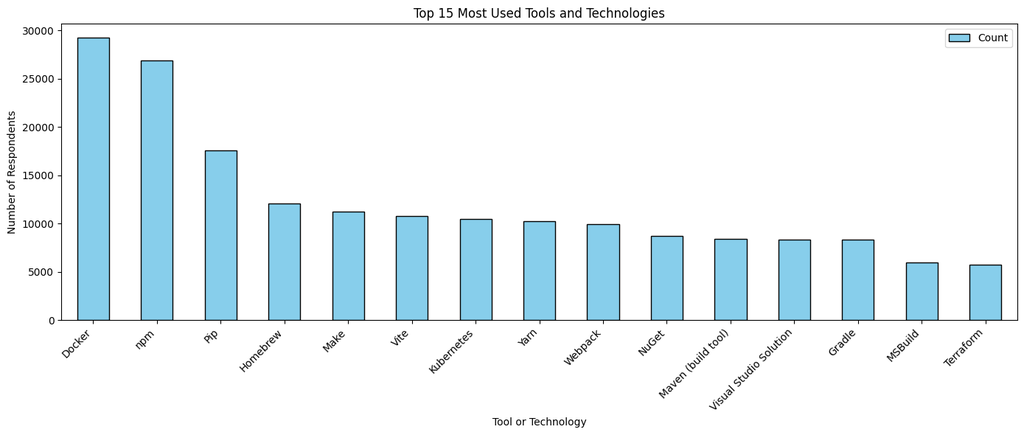

# Key Insights

- The most used tool is Docker, signifying the importance of faster testing and deployment of applications by isolating them from the system in Docker containers.
- It is followed by npm and pip, which are package managers for Node.js and Python respectively, highlight ing the popularity of these ecosystems.

The grouped bar chart below shows the most used operating systems for personal and professional use in 2024.

[figure not shown]

# Key Insights

- Windows continues to be the most used operating system for both, personal and professional use.
- Followed MacOS and Ubuntu, which are some of the most popular unix bases operating systems.
- We also see some mobile operating systems such as the Android and iOS.

The graph below shows the most used AI models in 2024.

[figure not shown]

# Key Insights

- ChatGPT is the most used AI model in 2024. By offering some free features, OpenAI has attracted a large audience for their product.
- ChatGPT is followed by GitHub Copilot and Google Gemini, which are also efficient AI models.

# **Employment and Work Preferences**

In this section, we will explore the employment status and work preferences of developers. This includes an analysis of their job roles, work environments, remote work trends, and factors influencing job satisfaction. By understanding these aspects, we can gain insights into the professional lives of developers and the evolving nature of work in the tech industry.

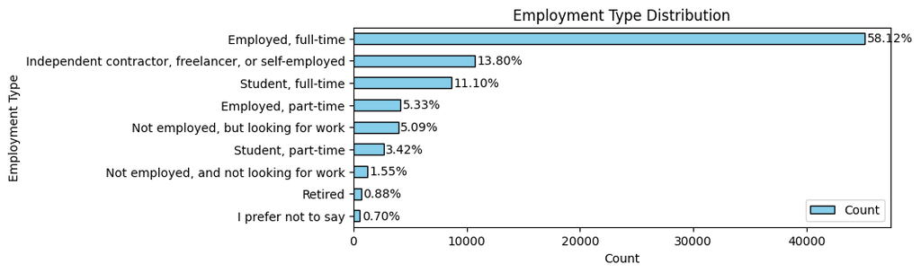

# Key Insights

- A lot of the respondents say that they are employed full time, amounting to almost 58%.
- 11.1% of the respondents are full time students.
- Almost 5% of the respondents are unemployed but are open to work opportunities, unlike the 1.5% of the unemployed developers who are not looking for work.

Let's now look at what job roles are most popular

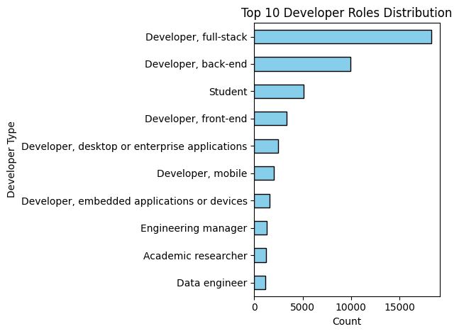